# How do Demographics Influence Oscar Wins in Lead Roles and Directing?

Kamila Lednická, Sára Košelíková, Klaudie Polednová, Kateřina Černá

2025-05-07

# **Preparing & Transforming data**

```r
head(df1)
summary(df1)
nrow(df1)
ncol(df1)
dim(df1)
str(df1)
sapply(df1, class)
```

```r
head(df2)
summary(df2)
nrow(df2)
ncol(df2)
dim(df2)
str(df2)
sapply(df2, class)
```

- The `movies data` dataset contains information about movies, received nominations and awards.
- It has information about films, category of win, years of film and ceremony, and wheter the nomination won or not.
- It has 3974 rows and 16 columns.
- The dataset includes integer and character and numeric values.

## **Subsetting Demographics**

We decided to subset original dataset to only columns we need and that make sense for our analysis.

```r
# subsetting columns
demographics <- df1[c("X_unit_id","birthplace", "date_of_birth", "race_ethnicity", "religion", "sexual_orientation","year_of_award","award", "movie", "person")]

# taking a look at the data
summary(demographics)
```

```
##    X_unit_id          birthplace        date_of_birth      race_ethnicity
##  Min.   :670454353   Length:441         Length:441         Length:441
##  1st Qu.:670454463   Class :character   Class :character   Class :character
##  Median :670454573   Mode  :character   Mode  :character   Mode  :character
##  Mean   :670482470
##  3rd Qu.:670454683
##  Max.   :670972898
##    religion         sexual_orientation year_of_award     award
##  Length:441         Length:441         Min.   :1927   Length:441
##  Class :character   Class :character   1st Qu.:1953   Class :character
##  Mode  :character   Mode  :character   Median :1973   Mode  :character
##                                        Mean   :1973
##                                        3rd Qu.:1994
##                                        Max.   :2014
##     movie              person
##  Length:441         Length:441
##  Class :character   Class :character
##  Mode  :character   Mode  :character
##
##
##
```

## **Missing values**

Next, we will take care of missing values:

```r
colSums(is.na(demographics))
```

```
##          X_unit_id         birthplace      date_of_birth     race_ethnicity
##                  0                  2                  0                  0
##           religion sexual_orientation      year_of_award              award
##                269                 11                  0                  0
##              movie             person
##                  0                  0
```

**RELIGION**

There are several missing values for religion, we decided to include `Unknown` value for religion.

```r
# Setting NAs in religion as "Unknown" religion
demographics$religion[is.na(demographics$religion)] <- "Unknown"

# Checking all religions
unique(demographics$religion)
```

```
##  [1] "Unknown"               "Roman Catholic"        "Jewish"
##  [4] "Presbyterian"          "Baptist"               "Atheist"
##  [7] "See Note"              "Anglican/episcopalian" "Deist"
## [10] "Protestant"            "Lutheran"              "Quaker"
## [13] "Born-Again Christian"  "Buddhist"              "Christian Science"
## [16] "Sufism"                "Disciples of Christ"   "Hindu"
## [19] "Christian"             "Methodist"             "Agnostic"
## [22] "Congregationalist"
```

```r
# Replacing "See Note" religion with "Unknown"
demographics$religion[demographics$religion == "See Note"] <- "Unknown"
```

After taking a closer look at all of the religions, it seem like there was an error in creation of one instance. The `See Note` religion doesn’t exist as we discovered after a quick search, it is most likely a problem created in data entry. We have decided to set the religion as `Unknown` instead.

**SEXUAL ORIENTATION**

Next, we will handle the missing values in sexual orientation. There are 11 missing values. We decided to add them to the already existing category `Matter of Dispute`.

```r
demographics[is.na(demographics$sexual_orientation),]$sexual_orientation <- "Matter of Dispute"
```

**BIRTH PLACE**

The only other missing values we have encountered are in the column `birthplace`. There are only 2 missing values and since this info is probably publicly available we could fix this manually, but instead we will perform **pairwise deletion** in case we need this variable in future analyses.

## **Transformation**

**COUNTRY**

We will create a new variable `country` from the variable `birthplace` by which we can analyze Oscar winners. The main purpose of this simplification is the excessive granularity of the data. There would be very little Oscar winners in each city if we kept this level of detail, that is why we have decided to generalize more.

```r
# Taking a look at the current values in the "birthplace" column.
head(demographics$birthplace)
```

```
## [1] "Chisinau, Moldova"  "Glasgow, Scotland"  "Chisinau, Moldova"
## [4] "Chicago, Il"        "Salt Lake City, Ut" "Glasgow, Scotland"
```

In the next step we will perform the transformation.

```r
# Fixing some incorrectly imported values in "birthplace"
demographics[59,]$birthplace <- "Čáslav, Czechoslovakia"
demographics[50,]$birthplace <- "Čáslav, Czechoslovakia"


# Function for extracting the last value after "," in "birthplace" column
extract_last_location <- function(x) {
  sub(".*,\\s*", "", x)
}

demographics$birthcountry<- sapply(demographics$birthplace, extract_last_location)


# Creating a vector of all the abbreviations of state names in the United States of America
us_states <- c("AL", "AK", "AZ", "AR", "CA", "CO", "CT", "DE", "FL", "GA",
               "HI", "ID", "IL", "IN", "IA", "KS", "KY", "LA", "ME", "MD",
               "MA", "MI", "MN", "MS", "MO", "MT", "NE", "NV", "NH", "NJ",
               "NM", "NY", "NC", "ND", "OH", "OK", "OR", "PA", "RI", "SC",
               "SD", "TN", "TX", "UT", "VT", "VA", "WA", "WV", "WI", "WY", "New York City")

# Function for the replacement of abbreviated state for USA as a country
replace_states <- function(country) {
  cleaned <- toupper(trimws(country))
  if (cleaned %in% us_states) {
    return("USA")
  } else {
    return(country)
  }
}

demographics<- demographics %>%
  mutate(country = unname(sapply(birthcountry, replace_states)))


# Displaying the final results in the column "country"
head(demographics$country)
```

```
## [1] "Moldova"  "Scotland" "Moldova"  "USA"      "USA"      "Scotland"
```

**Date of birth problem**

```
##  [1] "30-Sep-1895" "2-Feb-1886"  "30-Sep-1895" "23-Feb-1899" "23-Apr-1894"
##  [6] "2-Feb-1886"  "18-May-1897" "1-Feb-1894"  "18-May-1897" "3-Oct-1898"
## [11] "18-May-1897" "23-Feb-1883" "1-Feb-1894"  "1-Feb-1894"  "1-Jul-1902"
## [16] "24-Dec-1886" "3-Oct-1898"  "11-Oct-18"   "22-Jun-06"   "1-Jul-1902"
## [21] "7-Sep-09"    "5-Aug-06"    "11-Feb-09"   "11-Feb-09"   "18-Dec-04"
## [26] "1-Feb-1894"  "29-Apr-07"   "7-Sep-09"    "30-Jan-20"   "18-Dec-04"
```

The quality of `date_of_birth` column is so poor it would need manual correction. We were considering omitting it completely, but we have decided to try and salvage some of the data.

For this purpose, we created a copy of our demographics dataset in order to not loose any of our other relevant data in the process of `date_of_birth` column correction.

```r
# Creating a copy of our dataset
demographics_age <- demographics

# Removing "date_of_birth" from our main dataset
demographics <- subset(demographics, select = -date_of_birth)
```

**AGE**

For the extraction of `age` variable we will need to fix the `date_of_birth` variable values considerably. Since it is not completely clear which year of birth was intended originally, we will have to make a few assumptions.

```r
# Filtering only the rows we need
key_categories <- demographics_age %>%
  filter(award %in% c("Best Actor", "Best Actress", "Best Director"))

# Function for fixing some wrongly imported dates with square brackets
clean_date_str <- function(date_str) {
  clean <- sub("\\[.*$", "", date_str)
  clean <- trimws(clean)
  return(clean)
}

# Converting the date string into a standardized format DD-MM-YYYY.
fix_date <- function(date_str) {
  date_str <- clean_date_str(date_str)

  parts <- unlist(strsplit(date_str, "-"))
  if (length(parts) != 3) return(NA)

  day <- sprintf("%02d", as.numeric(parts[1]))
  month_map <- c("Jan" = "01", "Feb" = "02", "Mar" = "03", "Apr" = "04",
                 "May" = "05", "Jun" = "06", "Jul" = "07", "Aug" = "08",
                 "Sep" = "09", "Oct" = "10", "Nov" = "11", "Dec" = "12")
  month <- month_map[parts[2]] # mapping the month abbreviation to its numeric representation.
  if (is.na(month)) return(NA)

  year_raw <- parts[3]
  year <- suppressWarnings(as.numeric(year_raw))
  if (is.na(year)) return(NA)

  if (nchar(year_raw) == 2) {  #If the year is 2 digits → convert to 1900 + year
    year <- 1900 + year
  } else if (nchar(year_raw) == 4) {  #If the year is 4 digits it is okay
    year <- year
  } else {
    return(NA)
  }
  return(sprintf("%s-%s-%d", day, month, year))
}

key_categories$birth_fixed <- sapply(key_categories$date_of_birth, fix_date)

# removing NAs
key_categories <- key_categories[!is.na(key_categories$birth_fixed), ]

# calculating the current age of the person from the acquired date of birth
key_categories$age <- floor(as.numeric(difftime(Sys.Date(), as.Date(key_categories$birth_fixed, format = "%d-%m-%Y"), units = "days")) / 365.25)

# creating a variable with only the birth year from the fixed date of birth
key_categories$birth_year <- as.numeric(format(as.Date(key_categories$birth_fixed, format = "%d-%m-%Y"), "%Y"))

# calculating the age at the time of the award
key_categories$age_while_award <- key_categories$year_of_award - key_categories$birth_year
```

## **Subsetting Movies Info**

Once again we decided to subset original dataset to only columns we need and that are make sense for our analysis.

```r
# Subsetting the columns
movieinfo <- df2[c("Movie","Running.time","Genre","Budget","Box.Office","Actors.Box.Office..","Director.Box.Office..","Earnings", "Oscar.and.Golden.Globes.nominations","Oscar.and.Golden.Globes.awards", "IMDb.score")]

head(movieinfo)
```

```
##              Movie Running.time  Genre   Budget Box.Office Actors.Box.Office..
## 1         13 Hours          144 Action 50000000   6.94e+07               50.00
## 2        16 Blocks          102 Action 52000000   6.50e+07               33.33
## 3         17 Again          102 Comedy 20000000   1.39e+08               44.44
## 4             1982           90  Drama  1000000   2.00e+06               50.00
## 5 2 Fast 2 Furious          107 Action 76000000   2.36e+08               75.00
## 6           2 Guns          109 Action 61000000   1.32e+08               66.67
##   Director.Box.Office.. Earnings Oscar.and.Golden.Globes.nominations
## 1                 69.23 1.94e+07                                   0
## 2                 50.00 1.30e+07                                   0
## 3                 25.00 1.19e+08                                   0
## 4                100.00 1.00e+06                                   0
## 5                 42.85 1.60e+08                                   0
## 6                100.00 7.10e+07                                   0
##   Oscar.and.Golden.Globes.awards IMDb.score
## 1                              0        7.4
## 2                              0        6.6
## 3                              0        6.4
## 4                              0        7.1
## 5                              0        5.9
## 6                              0        6.7
```

### **Missing values**

The only missing values in this data set are in the `Oscar and Golden Globes awards` column, this doesn’t concern us since after the joining on the two datasets these instances are not among the ones that we are able to merge.

```r
# Looking at missing values
colSums(is.na(movieinfo))
```

```
##                               Movie                        Running.time
##                                   0                                   0
##                               Genre                              Budget
##                                   0                                   0
##                          Box.Office                 Actors.Box.Office..
##                                   0                                   0
##               Director.Box.Office..                            Earnings
##                                   0                                   0
## Oscar.and.Golden.Globes.nominations      Oscar.and.Golden.Globes.awards
##                                   0                                   3
##                          IMDb.score
##                                   0
```

```r
#Joining both datasets for all categories (actors, actresses and directors)


#normalization function
normalize_title <- function(title) {
  title <- iconv(title, to = "UTF-8", sub = "")  # Remove invalid encodings
  title <- tolower(title)# lowercase
  title <- gsub("[[:punct:]]", " ", title)#remove punctuation
  title <- gsub("\\s+", " ", str_trim(title))#whitespace
  return(title)
}


# normalizing movie titles in both datasets
demographics <- demographics %>%
  mutate(normalized_movie = normalize_title(movie))

movieinfo <- movieinfo %>%
  mutate(normalized_movie = normalize_title(Movie))

# Left fuzzy join using Levenshtein distance
joined_df <- merge(
  demographics,
  movieinfo,
  by = "normalized_movie",
  method = "lv",         # Levenshtein distance
  max_dist = 2           # Adjust based on how fuzzy the match should be
)

nrow(joined_df)
```

```
## [1] 205
```

## **Actor and director data frame for only demographics**

Now lets separate actors and directors into separate data-frames.

**For demographics**

```
## [1] "Number of rows in director dataframe:"
## [1] 91
## [1] "Number of rows in actor dataframe:"
## [1] 183
```

**For the joined demographics and movie info**

```
## [1] "Number of rows in joined director dataframe:"
## [1] 59
## [1] "Number of rows in joined actor dataframe:"
## [1] 76
```

Note: We will only use joined dataframes where necessary since we loose a lot of instances in this step. So `director_joined` and `actor_joined` will only be used for public opinion analysis.

# **Confidence Exploration**

Since we omit confidence from the rest of our analysis, we will at least briefly explore what it can tell us.

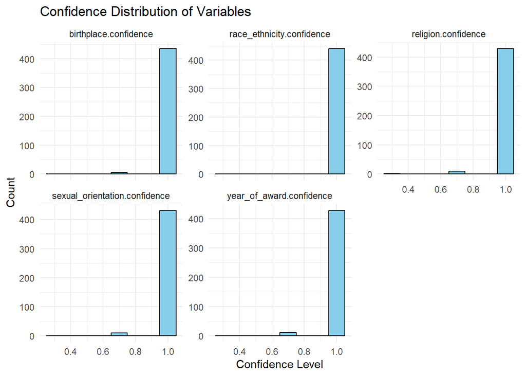

```r
df_summary <- df_long %>%
  group_by(variable) %>%
  summarise(
    avg_confidence = round(mean(confidence, na.rm = TRUE), 3),
    high_conf_pct = round(mean(confidence == 1, na.rm = TRUE) * 100, 1),
    total = n()
  )

print(df_summary)
```

```
## # A tibble: 5 × 4
##   variable                      avg_confidence high_conf_pct total
##   <chr>                                  <dbl>         <dbl> <int>
## 1 birthplace.confidence                  0.995          98.2   441
## 2 race_ethnicity.confidence              0.999          99.5   441
## 3 religion.confidence                    0.989          96.6   441
## 4 sexual_orientation.confidence          0.992          97.5   441
## 5 year_of_award.confidence               0.99           96.4   441
```

According to confidence columns the data is reliable, all confidence is above 95 %. But it is not 100 % so we have to be careful with results.

# **Demographics Of Academy Awards Winners**

## **Exploration Of Age**

We started by calculating basic statistics.

```r
age_summary <- aggregate(age_while_award ~ award,
                         data = key_categories,
                         FUN = summary)

print(age_summary)
```

```
##           award age_while_award.Min. age_while_award.1st Qu.
## 1    Best Actor             30.00000                39.00000
## 2  Best Actress             22.00000                29.00000
## 3 Best Director             32.00000                41.25000
##   age_while_award.Median age_while_award.Mean age_while_award.3rd Qu.
## 1               43.50000             45.04545                51.00000
## 2               34.00000             36.42105                39.50000
## 3               46.00000             47.35556                53.00000
##   age_while_award.Max.
## 1             77.00000
## 2             81.00000
## 3             75.00000
```

- Male Actors peak around 44 years of age, with only a few winners below 39 and above 51.
- Female Actresses peak around 34 years of age, with only a few winners below 29 and above 39.
- Directors in general peak around the age of 46 with only a few winners below 41 and above 53.

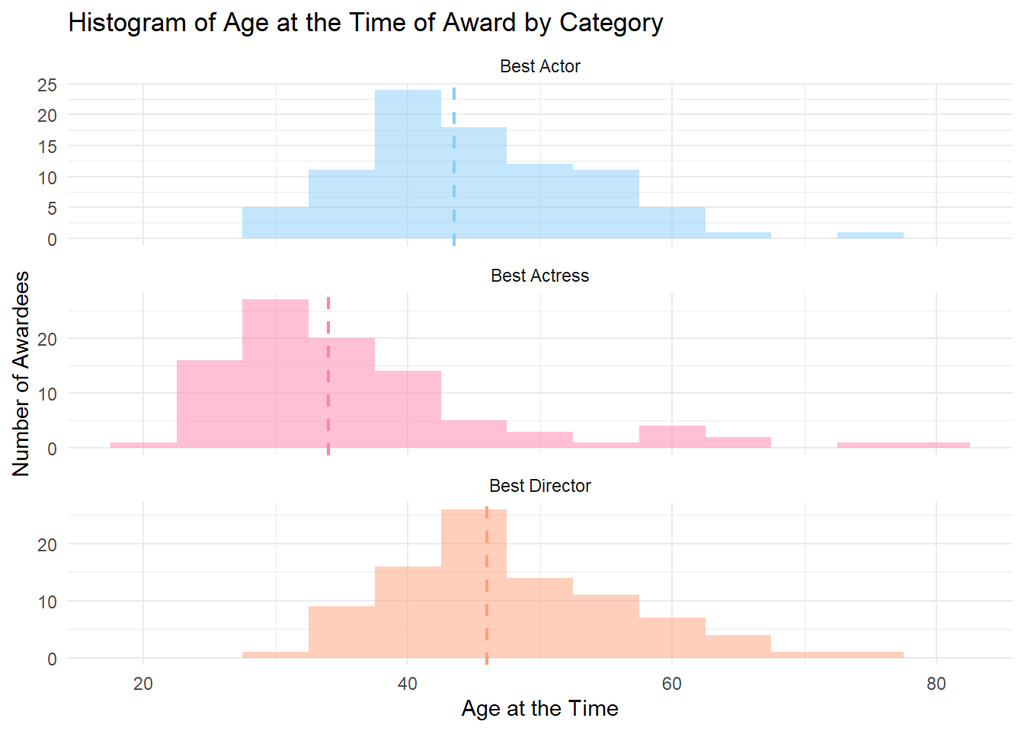

Overall there is a right-skew in all of these categories. Actresses especially have a younger skew, compared to actors/directors.

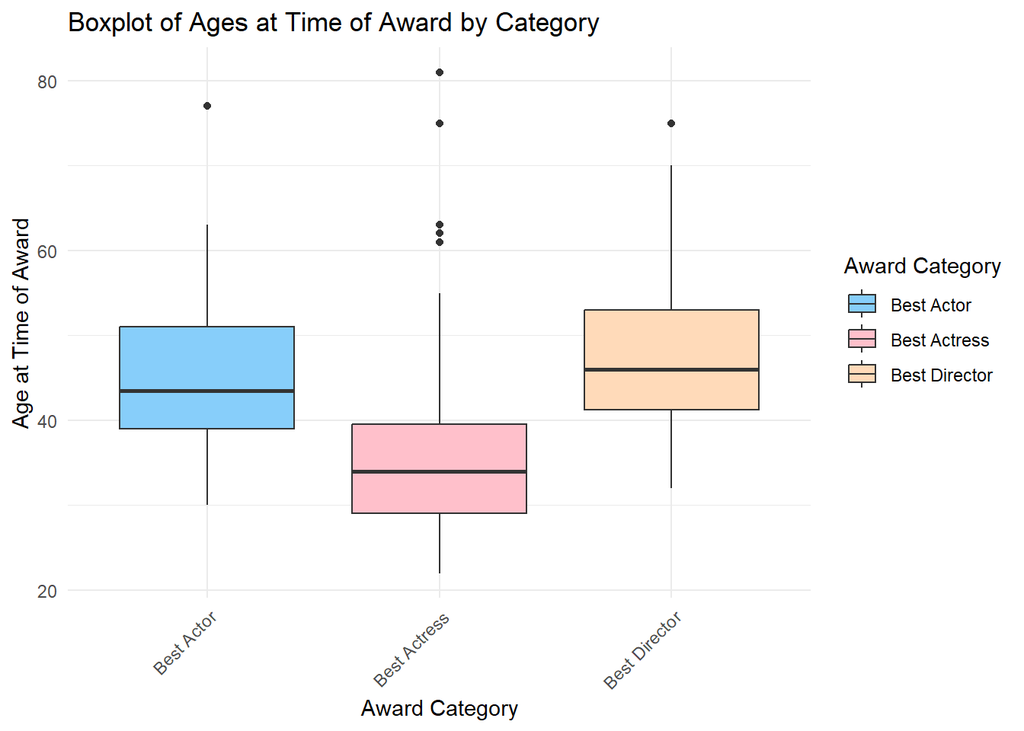

Though there are some outliers (later age award receivers) in the actress category there seems to be an age disparity in the awards. We will test this using ANOVA.

```r
# Quantifying the disparities
model_1 <- aov(age_while_award~award, key_categories)
summary(model_1)
```

```
##              Df Sum Sq Mean Sq F value   Pr(>F)
## award         2   6177  3088.6   32.75 1.84e-13 ***
## Residuals   270  25464    94.3
## ---
## Signif. codes:  0 '***' 0.001 '**' 0.01 '*' 0.05 '.' 0.1 ' ' 1
```

```r
EtaSq(model_1)
```

```
##          eta.sq eta.sq.part
## award 0.1952267   0.1952267
```

The Anova results reveal statistically significant differences in the age at which awards are received across all categories. Almost 20 % of age variance is explained by award category.

## **Exploration Of Gender**

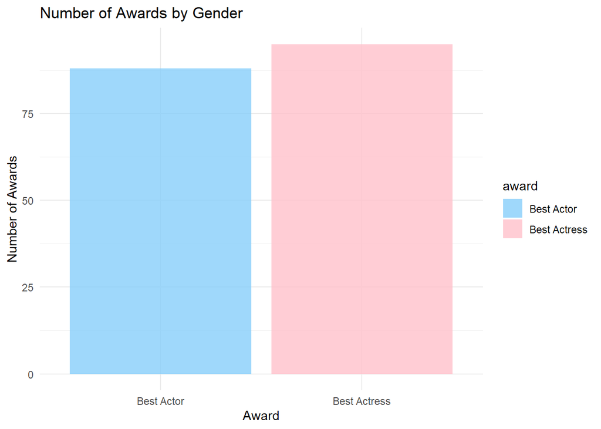

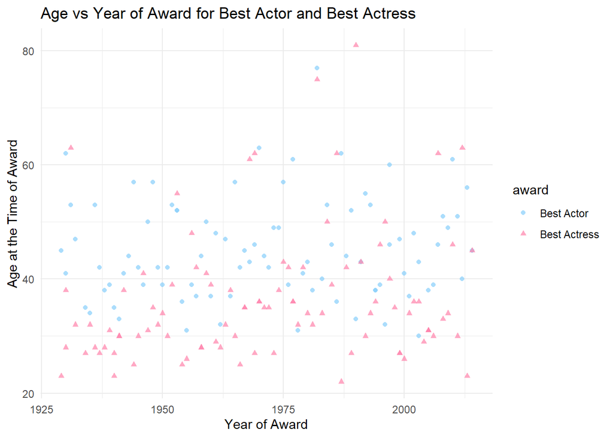

- The data shows that more actresses were awarded than actors.
- Women receive the most awards between the ages of 20 and 40.
- Male actors receive the most awards between the ages of 35 and 55.

We will remove some outliers for regression analysis:

```r
data = key_categories[,c("year_of_award","age_while_award")]

mahalanobis_distances <- mahalanobis(data, colMeans(data), cov(data))
critical_value = qchisq(0.975, df = ncol(data))
outliers = data[mahalanobis_distances > critical_value, ]
outliers
```

```
##     year_of_award age_while_award
## 79           2005              75
## 141          1982              77
## 177          1931              63
## 228          1982              75
## 236          1990              81
## 259          2013              23
```

```r
key_categories<- key_categories[!(mahalanobis_distances > critical_value), ]
```

**Regression model & testing for homogeneity of variance:**

```r
model_age<- lm(age_while_award ~ year_of_award, data = key_categories)
summary(model_age)
```

```
##
## Call:
## lm(formula = age_while_award ~ year_of_award, data = key_categories)
##
## Residuals:
##      Min       1Q   Median       3Q      Max
## -21.4263  -7.0587  -0.3619   6.4717  25.4267
##
## Coefficients:
##                Estimate Std. Error t value Pr(>|t|)
## (Intercept)   -99.01967   48.14355  -2.057  0.04069 *
## year_of_award   0.07169    0.02442   2.935  0.00362 **
## ---
## Signif. codes:  0 '***' 0.001 '**' 0.01 '*' 0.05 '.' 0.1 ' ' 1
##
## Residual standard error: 9.761 on 265 degrees of freedom
## Multiple R-squared:  0.03149,    Adjusted R-squared:  0.02784
## F-statistic: 8.617 on 1 and 265 DF,  p-value: 0.003623
```

```r
#homogeneity of variance for quantitative variables
fligner.test(age_while_award ~ year_of_award, data = key_categories)
```

```
##
##  Fligner-Killeen test of homogeneity of variances
##
## data:  age_while_award by year_of_award
## Fligner-Killeen:med chi-squared = 65.4, df = 86, p-value = 0.9521
```

Year of the award explains some of the variability in age at which the award won, but only about 3 %. The age at which awards are received has remained relatively consistent.Test for homogeneity shows that the relationship is homogeneous, for us it means that the data doesn’t show a trend towards greater age inclusiveness.

## **Exploration Of Countries**

```
## [1] "Number of USA winners:"
## [1] 286
## [1] "Number of non-USA winners:"
## [1] 155
## [1] "Ratio of USA to non-USA Oscar winners"
## [1] 0.6485261
```

- There are 286 people from USA who won an Oscar in the years 1927-2014, 155 are from all other countries.
- Americans make up about 65 % of all winners

**Have the proportions changed over time?**

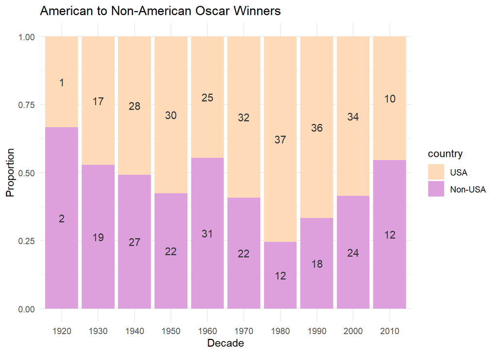

The proportion of USA winners fluctuates over the decades with notable peak in 1980s. Since then there seems to be a trend towards greater international representation.

# **Underrepresented groups & inclusivity over time**

Heatmap of ethnicity vs sexual orientation.

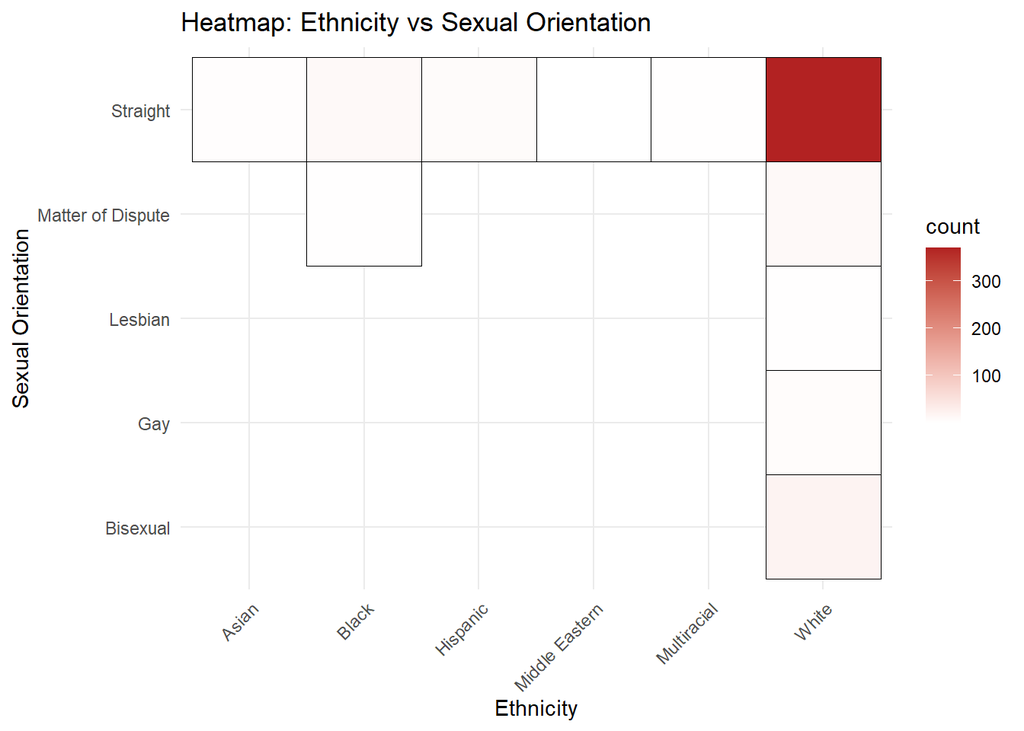

The most dominant group by far is White & Straight, followed by White & Bisexual. There is virtually no representation for non-white queer individuals. Several combinations are either extremely rare or entirely missing from the data, highlighting intersectional underrepresentation.

## **Queer individuals**

Relationship between `award` and `sexual_orientation`:

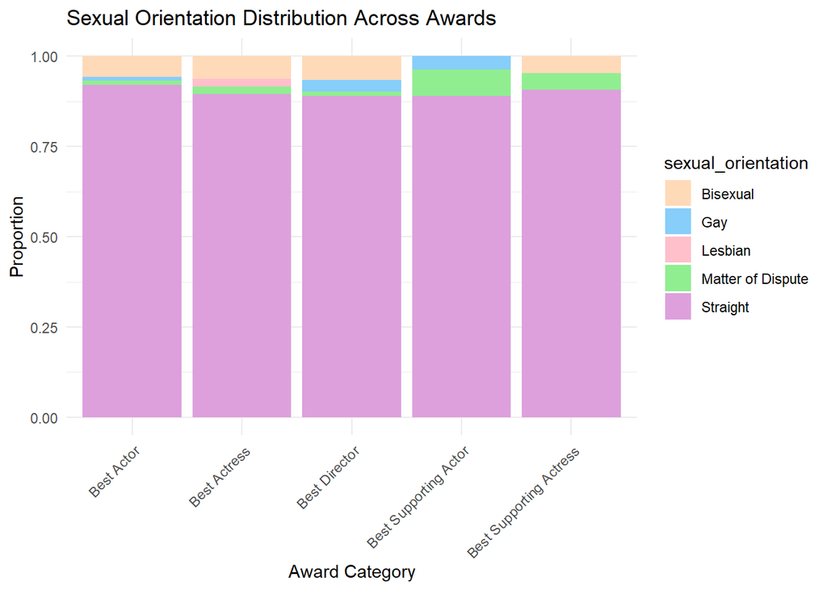

It clearly shows that the majority of winners identify as straight in all categories. Queer individuals are present across all award types, but always as a small minority.

```
## [1] "Percentage of queer winners from total winners:"
## [1] 6.802721
## [1] "Years in which queer individual has won and award:"
##  [1] 1929 1934 1936 1941 1942 1946 1949 1953 1955 1958 1959 1962 1964 1965 1967
## [16] 1968 1969 1973 1982 1988 1989 1992 1994 2000
```

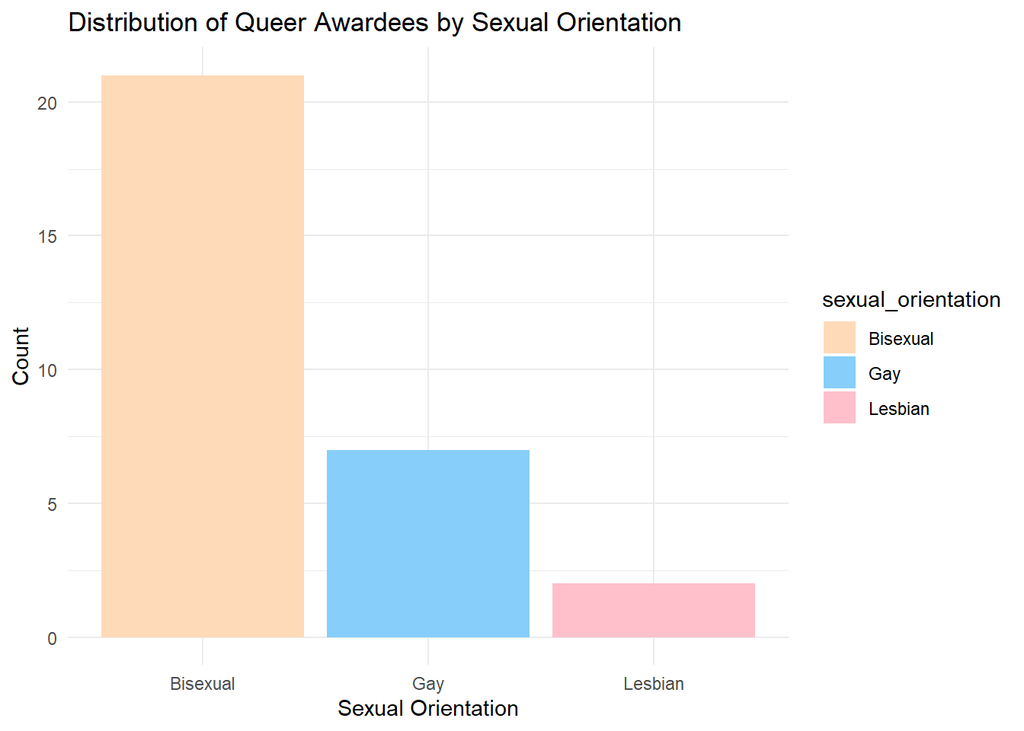

There are 30 queer people in our dataset. 21 of them are bisexual, 7 are gay and 2 are lesbian. That means only 6.8 % of award winners are not straight, but according to estimated values about 7 % of the whole population is not straight.That means that the distribution is very similiar to overall world population. So we decided that queer people are not underrepresented.

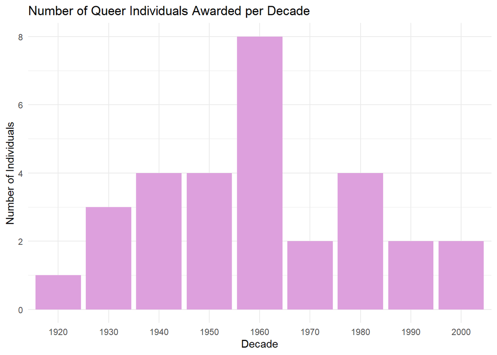

This graph shows us how many queer people recieved an oscar per decade

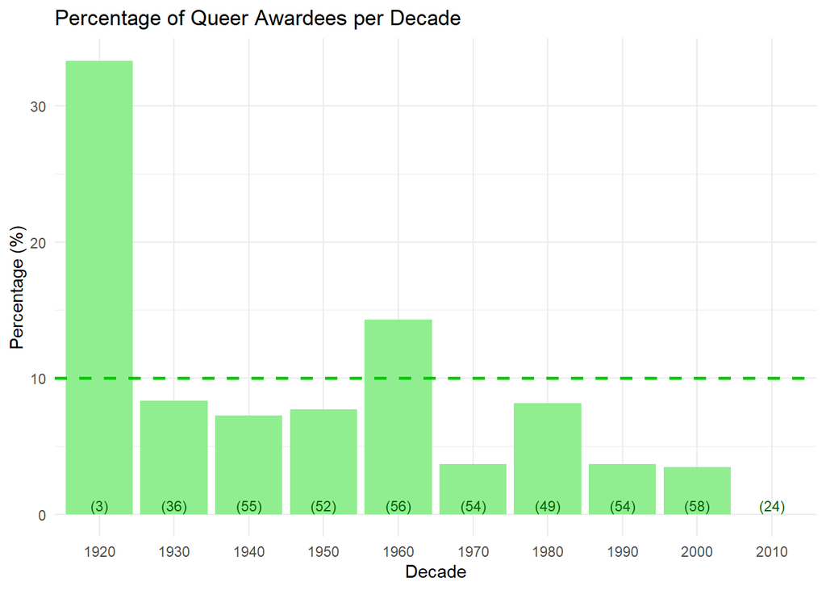

This graph is similar to the previous one, but it shows the proportion of queer individuals among all awardees.

- In the graph distribution per - it was counted as (number of queer poeple per decade):(total number of oscar winners per decade)
- The number in brackets just above x-axis shows total number of oscar winners per decade
- we can see that 1920 has a big % of non straight people this is due to the fact that there are only 3 values from 1920, one of them not straight, making queer population 33%

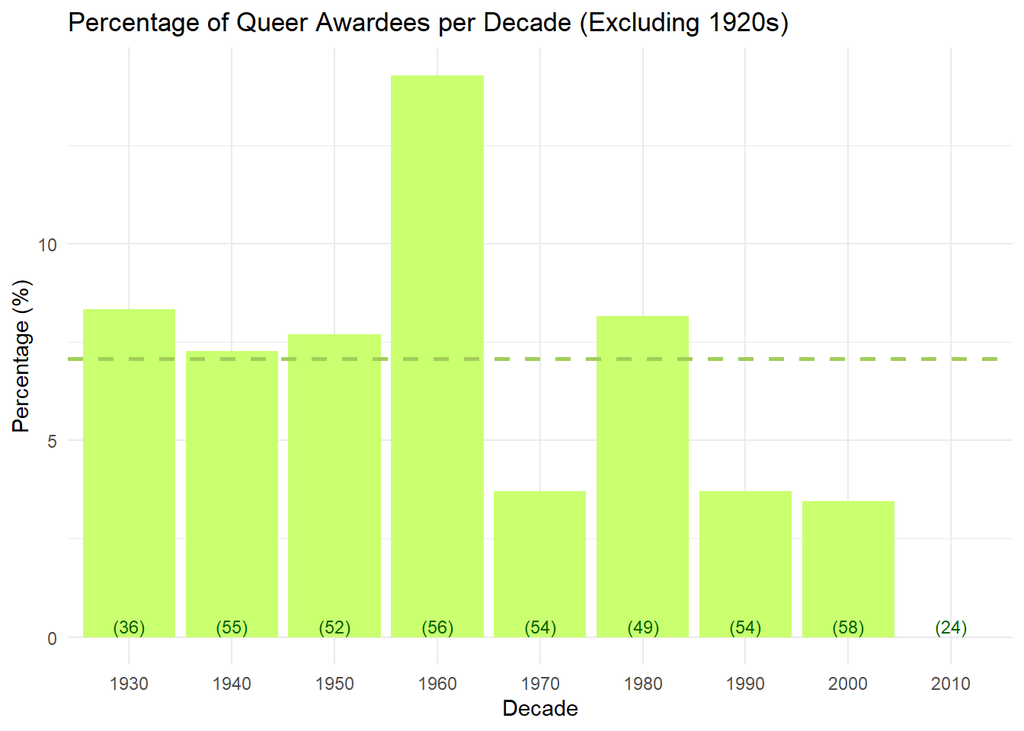

- In the second graph, without 1920s, the values are closer together.
- The mean is around 7% as we said before.
- We can see that this graph is much closer in distribution to the one showing absolute values (Number of Queer Individuals Awarded per Decade).
- There were truly more queer people than is usual in 1960s and it was not due to some lack of data as we saw in 1920s.

**The first queer actors to win Oscar award**

```
##   year_of_award           person                          movie
## 1          1989     Jodie Foster                    The Accused
## 2          1934 Charles Laughton The Private Life of Henry VIII
## 3          1929    Emil Jannings               The Last Command
##   sexual_orientation race_ethnicity
## 1            Lesbian          White
## 2                Gay          White
## 3           Bisexual          White
```

## **Non-white individuals**

```
##  [1] X_unit_id          birthplace         race_ethnicity     religion
##  [5] sexual_orientation year_of_award      award              movie
##  [9] person             birthcountry       country            normalized_movie
## [13] decade
## <0 rows> (or 0-length row.names)
```

- There are 30 non white people, the same number as queer people
- They are not the same poeple
- There isn’t any non straight and non white person in our data

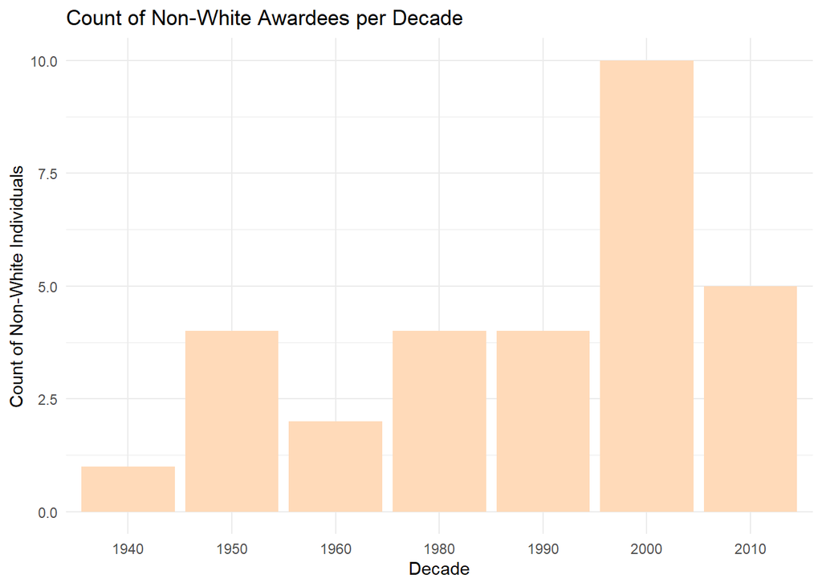

- We can see that most of the non white people were awarded in 2000s
- There were no non white awards in 1920, 1930 and 1970
- Only 6.8 % of all oscards winners weren’t white

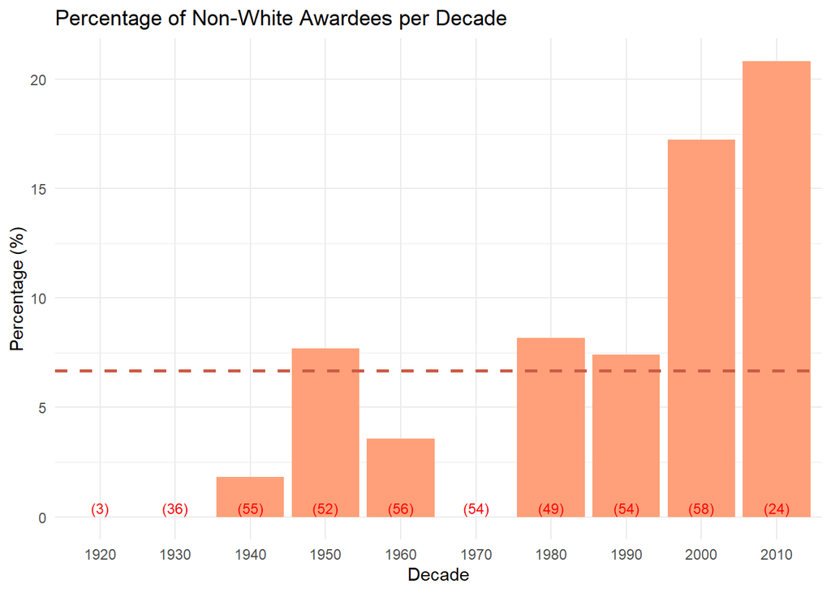

- This graph represents % of non white oscar winners per decade
- It is a bit different from the graph before
- We can see that it distribution of nonwhite awardees in 2010s is higher than in 2000s
- We didn’t see this before because there were less values in 2010 since the dataset ends in 2014
- Above 20% people were nonwhite 1 of 5 oscar winners in 2010

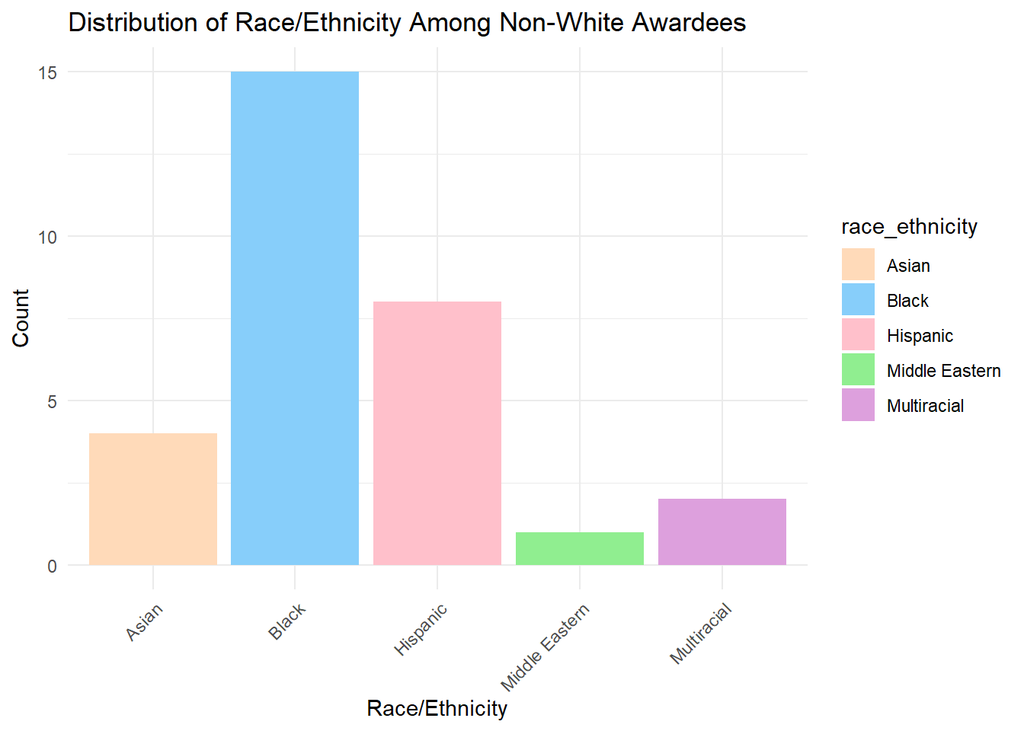

- 50 % of the non white people are black
- The least represented are Middle Eastern, Multiracial and Asian

```
## [1] "Distribution of race and ethnicity in the US in [%]"
## $White
## [1] 57.8
##
## $Hispanic
## [1] 18.7
##
## $Black
## [1] 12.1
##
## $Asian
## [1] 5.9
##
## $MultiRacial
## [1] 4.1
##
## $Native_American_Alaska_Native
## [1] 0.7
##
## $Native_Hawaiian_Other_Pacific_Islander
## [1] 0.2
```

- This list contains the percentage distribution of races in the United States.
- We chose to compare it to the racial makeup of Oscar nominees,
- even though nominations can come from any country, most of them are from USA

```
## [1] "Distribution of race and ethnicity in the World in [%]"
##
##          Asian          Black       Hispanic Middle Eastern    Multiracial
##      0.9070295      3.4013605      1.8140590      0.2267574      0.4535147
```

```
## [1] 0.1184211
```

Hispanic individuals are the most underrepresented in the data set compared to the USA racial distribution in 2025.

In contrast, Black individuals are the least underrepresented, with 12 % of the USA population being Black, while the data set reflects 3.4 % of Black nominees. That is 4 times less. But after year 2000 about 12 % of awardees were Black, that is the same number as percentage of black people in the United states.

So in summary all non white people are underrepresented according to USA racial distribution in 2025 when we look at all data. However this data goes back a hundred years and racial distribution in USA has changed over the years.

- The white population used to be much bigger (89.7% in 1920 compared to 61% in 2020).
- Black population has been getting bigger about 1% each year.
- There are more and more multiracial people.

Representation of non white people has been rising. Black people have not been underrepresented since the year 2000.

It’s important to note that the data used is over 10 years old and newer data may have very different results.

**The first non-white actors to win Oscars**

```
##   year_of_award            person               movie race_ethnicity
## 1          1951       Jose Ferrer  Cyrano de Bergerac       Hispanic
## 2          1964    Sidney Poitier Lilies of the Field          Black
## 3          1983      Ben Kingsley              Gandhi    Multiracial
## 4          1985 F. Murray Abraham             Amadeus Middle Eastern
##   sexual_orientation
## 1           Straight
## 2           Straight
## 3           Straight
## 4           Straight
```

# **Reaction Of The General Public**

```
## [1] "Number of each sexual minority in our joined dataframe:"
## # A tibble: 4 × 2
##   sexual_orientation total
##   <chr>              <int>
## 1 Bisexual               5
## 2 Lesbian                1
## 3 Matter of Dispute      2
## 4 Straight              68
```

```
## [1] "Number of each racial/ethnical minority in our joined dataframe:"
## # A tibble: 4 × 2
##   race_ethnicity total
##   <chr>          <int>
## 1 Black              3
## 2 Middle Eastern     1
## 3 Multiracial        2
## 4 White             70
```

We decided to join race_ethnicity column into two categories only - the `Minority` and `White`. It is mainly because white people dominate the Oscars.

```r
# Joining race and ethnicity
actor_joined <- actor_joined %>%
  mutate(category_ethnicity = case_when(
    race_ethnicity %in% c("Asian","Hispanic","Black","Multiracial","Middle Eastern") ~ "Minority",
    race_ethnicity == "White" ~ "White",
    TRUE ~ NA_character_
  ))


director_joined <- director_joined %>%
  mutate(category_ethnicity = case_when(
    race_ethnicity %in% c("Asian","Hispanic","Black","Multiracial","Middle Eastern") ~ "Minority",
    race_ethnicity == "White" ~ "White",
    TRUE ~ NA_character_
  ))
```

For the sexual_orientation we decided to do the same only this time we have the `Queer` and `Straight` category.

```r
# Joining sexual orientation
actor_joined <- actor_joined %>%
  mutate(category = case_when(
    sexual_orientation %in% c("Bisexual", "Lesbian", "Matter of Dispute") ~ "Queer",
    sexual_orientation == "Straight" ~ "Straight",
    TRUE ~ NA_character_
  ))

director_joined <- director_joined %>%
  mutate(category = case_when(
    sexual_orientation %in% c("Bisexual", "Lesbian", "Matter of Dispute") ~ "Queer",
    sexual_orientation == "Straight" ~ "Straight",
    TRUE ~ NA_character_
  ))
```

**Distribution of of actors with and without assigned IMDb scores over the years**

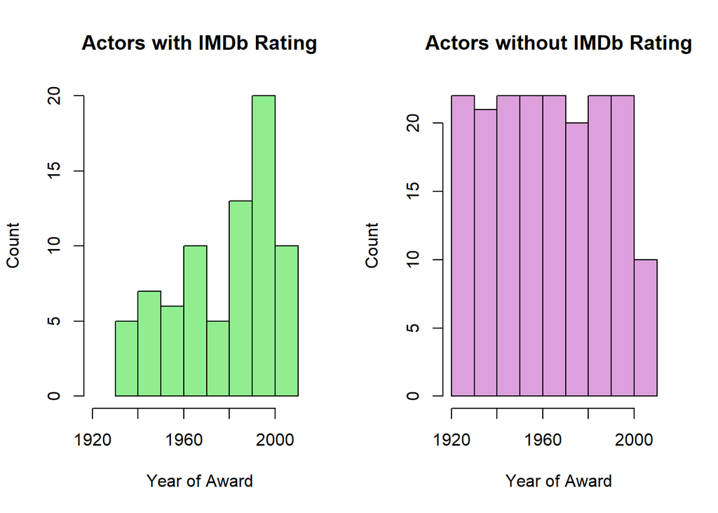

We chose median instead of mean for comparisons, since we are aware of a few outliers and we don’t want them to influence our results disproportionately.

**RACE/ETHNICITY**

```r
analysis <- actor_joined %>%
  group_by(category_ethnicity) %>%
  summarise(
    med_IMDb_score = median(IMDb.score, na.rm = TRUE),
    med_box_office = median(Box.Office, na.rm = TRUE),
    med_box_office_actor = median(Actors.Box.Office.., na.rm = TRUE),
    med_budget = median(Budget, na.rm = TRUE)
  )

print(analysis)
```

```
## # A tibble: 2 × 5
##   category_ethnicity med_IMDb_score med_box_office med_box_office_actor
##   <chr>                       <dbl>          <dbl>                <dbl>
## 1 Minority                      7.7       78000000                 86.7
## 2 White                         7.9       93000000                 73.6
## # ℹ 1 more variable: med_budget <dbl>
```

Minority-led films have higher actor-level box office and higher budgets. White-led films perform better at the box office overall and have slightly higher IMDb Scores.

The higher budget and comparable rating for minority-led films suggest these are not underperforming, though they may be underproduced.

[figure not shown]

**IMDb Score:** White actors have slightly higher median IMDb score, but the difference is small, suggesting that critical reception is roughly comparable.

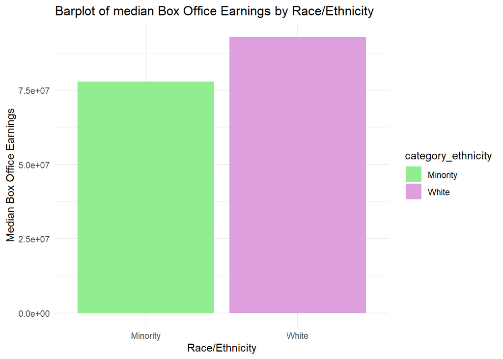

[figure not shown]

[figure not shown]

```
## [1] "Comparison of film box office, awards and individual box office values by race/ethnicity"
## # A tibble: 2 × 5
##   category_ethnicity med_IMDb_score med_box_office med_box_office_actor
##   <chr>                       <dbl>          <dbl>                <dbl>
## 1 Minority                      7.7       78000000                 86.7
## 2 White                         7.9       93000000                 73.6
## # ℹ 1 more variable: med_budget <dbl>
```

**SEXUAL ORIENTATION**

```
## [1] "Comparison of film box office, awards and individual box office values by sexual orientation"
## # A tibble: 2 × 5
##   category med_IMDb_score med_box_office med_box_office_actor med_budget
##   <chr>             <dbl>          <dbl>                <dbl>      <dbl>
## 1 Queer              8.2       148000000                 58.4   16500000
## 2 Straight           7.85       93000000                 83.3   14400000
```

[figure not shown]

On average, films with queer actors tend to slightly outperform films with straight actors in box office earnings and awards.

# **Conclusion**

The influence of demographics on the likelihood of winning an Oscar in leading roles and directing is substantial and historically biased. Age, race, gender and nationality all play significant roles in shaping Oscar outcomes:

While the Academy’s decisions have often reflected structural biases, more recent years suggest some progress towards greater inclusivity. Our limited IMDb data indicated no significant public backlash toward minority winners, implying that audiences are not resistant, if not supportive (especially in case of queer individuals), to more diverse representation among Oscar recipients.